# Final_xl2836

Xinyi Lin

11/17/2018

```r
library(tidyverse)
```

# Import and tidy data

First, we should have a roughly understanding about this data.

```r
#mentalhealth_2014_df = read_csv("./data/mental_health_in_tech_2014.csv")
mentalhealth_2016_df = read_csv("./data/mental_health_in_tech_2016.csv")
```

Variables name in this data set are questions, we change it to short words for easy-reading.

• Self_employed: Are you self-employed?

• Num_employees: How many employees does your company or organization have?

• Tech_company: Is your employer primarily a tech company/organization?

• Tech_role: Is your primary role within your company related to tech/IT?

• Benefits: Does your employer provide mental health benefits as part of healthcare coverage?

• Care_options: Do you know the options for mental health care available under your employer-provided coverage?

• Employer_discussion: Has your employer ever formally discussed mental health (for example, as part of a wellness campaign or other official communication)?

• Employer_help: Does your employer offer resources to learn more about mental health concerns and options for seeking help?

• Anonymity: Is your anonymity protected if you choose to take advantage of mental health or substance abuse treatment resources provided by your employer?

• Medical_leave: If a mental health issue prompted you to request a medical leave from work, asking for that leave would be:

• Mental_health_consequences: Do you think that discussing a mental health disorder with your employer would have negative consequences?

• Physical_health_consequences: Do you think that discussing a physical health issue with your employer would have negative consequences?

• Coworkers_discussion: Would you feel comfortable discussing a mental health disorder with your coworkers?

• Supervisor_discussion: Would you feel comfortable discussing a mental health disorder with your direct supervisor(s)?

• Mental_vs_physical: Do you feel that your employer takes mental health as seriously as physical health?

• Obs_consequence: Have you heard of or observed negative consequences for coworkers with mental health conditions in your workplace?

• Medical_coverage: Do you have medical coverage (private insurance or state-provided) which includes treatment of mental health issues?

• Help_resourcces: Do you know local or online resources to seek help for a mental health disorder?

• Whether_reveal_business_contacts: If you have been diagnosed or treated for a mental health disorder, do you ever reveal this to clients or business contacts?

• Reveal_concequences_business_contects: If you have revealed a mental health issue to a client or business contact, do you believe this has impacted you negatively?

• Whether_reveal_coworkers: If you have been diagnosed or treated for a mental health disorder, do you ever reveal this to coworkers or employees?

• Reveal_concequences_coworkers: If you have revealed a mental health issue to a coworker or employee, do you believe this has impacted you negatively?

• Productivity_affect: Do you believe your productivity is ever affected by a mental health issue?

• Work_time_affected: If yes, what percentage of your work time (time performing primary or secondary job functions) is affected by a mental health issue?

• Preemployers: Do you have previous employers?

• Preemployers_benefits:Have your previous employers provided mental health benefits?

• Preemployers_care_options: Were you aware of the options for mental health care provided by your previous employers?

• Preemployers_discussion: Did your previous employers ever formally discuss mental health (as part of a wellness campaign or other official communication)?

• Preemployer_help: Did your previous employers provide resources to learn more about mental health issues and how to seek help?

• Pre_anonymity: Was your anonymity protected if you chose to take advantage of mental health or substance abuse treatment resources with previous employers?

• Pre_mental_health_consequences: Do you think that discussing a mental health disorder with previous employers would have negative consequences?

• Pre_physical_health_consequences: Do you think that discussing a physical health issue with previous employers would have negative consequences?

• Pre_coworkers_discussion:Would you have been willing to discuss a mental health issue with your previous co-workers?

• Pre_supervisors_discussion: Would you have been willing to discuss a mental health issue with your direct supervisor(s)?

• Pre_mental_vs_physicalDid you feel that your previous employers took mental health as seriously as physical health?

• Pre_obs_consequenceDid you hear of or observe negative consequences for co-workers with mental health issues in your previous workplaces?

• Physical_health_interview: Would you be willing to bring up a physical health issue with a potential employer in an interview?

• Physical_health_interview_reason: Why or why not?

• Mental_health_interview: Would you bring up a mental health issue with a potential employer in an interview?

• Mental_health_interview_reason: Why or why not?

• Career_influence: Do you feel that being identified as a person with a mental health issue would hurt your career?

• Coworkers_view: Do you think that team members/co-workers would view you more negatively if they knew you suffered from a mental health issue?

• Friends_family_share: How willing would you be to share with friends and family that you have a mental illness?

• Unsupportive_badly_handled: Have you observed or experienced an unsupportive or badly handled response to a mental health issue in your current or previous workplace?

• Less_likely_reveal: Have your observations of how another individual who discussed a mental health disorder made you less likely to reveal a mental health issue yourself in your current workplace?

• Family_history: Do you have a family history of mental illness?

• Mental_health_previous: Have you had a mental health disorder in the past?

• Mental_health_now:Do you currently have a mental health disorder?

• Condition_diagnosed: If yes, what condition(s) have you been diagnosed with?

• Possible_condition: If maybe, what condition(s) do you believe you have?

• Professional_diagnosed: Have you been diagnosed with a mental health condition by a medical professional?

• Condition_professional_diagnosedIf so, what condition(s) were you diagnosed with?

• Seek_treatment: Have you ever sought treatment for a mental health issue from a mental health professional?

• Work_interferes_treated: If you have a mental health issue, do you feel that it interferes with your work when being treated effectively?

• Work_interferes_untreated:If you have a mental health issue, do you feel that it interferes with your work when NOT being treated effectively?

• Age: What is your age?

• Gender: What is your gender?

• Country_live: What country do you live in?

• Territory_live: What US state or territory do you live in?

• Country_work: What country do you work in?

• Territory_work: What US state or territory do you work in?

• Work_position: Which of the following best describes your work position?

• Work_remotely: Do you work remotely?

```r
colnames(mentalhealth_2016_df) <- c("self_employed", "num_employees", "tech_company", "tech_role", "benefits", "care_options", "employer_discussion", "employer_help", "anonymity", "medical_leave", "mental_health_consequences", "physical_health_consequences", "coworkers_discussion", "supervisor_discussion", "mental_vs_physical", "obs_consequence", "medical_coverage", "help_resourcces", "whether_reveal_business_contacts", "reveal_concequences_business_contects", "whether_reveal_coworkers", "reveal_concequences_coworkers", "productivity_affect", "work_time_affected", "preemployers", "preemployers_benefits", "preemployers_care_options", "preemployers_discussion", "preemployer_help", "pre_anonymity", "pre_mental_health_consequences", "pre_physical_health_consequences", "pre_coworkers_discussion", "pre_supervisors_discussion", "pre_mental_vs_physical", "pre_obs_consequence", "physical_health_interview", "physical_health_interview_reason", "mental_health_interview", "mental_health_interview_reason", "career_influence", "coworkers_view", "friends_family_share", "unsupportive_badly_handled", "less_likely_reveal", "family_history", "mental_health_previous", "mental_health_now", "condition_diagnosed", "possible_condition", "professional_diagnosed", "condition_professional_diagnosed", "seek_treatment", "work_interferes_treated", "work_interferes_untreated", "age", "gender", "country_live", "territory_live", "country_work", "territory_work", "work_position_kind", "work_remotely")
```

```r
summary(as.factor(mentalhealth_2016_df$gender))
```

```
##                                                                                                                                                         AFAB
##                                                                                                                                                            1
##                                                                                                                                                      Agender
##                                                                                                                                                            2
##                                                                                                                                                  Androgynous
##                                                                                                                                                            1
##                                                                                                                                                     Bigender
##                                                                                                                                                            1
##                                                                                                                                                   Cis female
##                                                                                                                                                            1
##                                                                                                                                                     cis male
##                                                                                                                                                            1
##                                                                                                                                                     Cis male
##                                                                                                                                                            1
##                                                                                                                                                     Cis Male
##                                                                                                                                                            1
##                                                                                                                                                      cis man
##                                                                                                                                                            1
##                                                                                                                                                    Cis-woman
##                                                                                                                                                            1
##                                                                                                                                                      cisdude
##                                                                                                                                                            1
##                                                                                                                                             Cisgender Female
##                                                                                                                                                            1
##                                                                                                                                                         Dude
##                                                                                                                                                            1
```

[output cut: 108 more lines]

```r
summary(as.factor(mentalhealth_2016_df$country_work))
```

```
##              Afghanistan                Argentina                Australia
##                        2                        1                       34
##                  Austria               Bangladesh                  Belgium
##                        4                        1                        5
##   Bosnia and Herzegovina                   Brazil                   Brunei
##                        2                       10                        1
##                 Bulgaria                   Canada                    Chile
##                        7                       74                        3
##                    China                 Colombia               Costa Rica
##                        1                        2                        1
##           Czech Republic                  Denmark                  Ecuador
##                        3                        7                        1
##                  Estonia                  Finland                   France
##                        2                        7                       14
##                  Germany                   Greece                Guatemala
##                       58                        1                        1
##                  Hungary                    India                     Iran
##                        1                        9                        1
##                  Ireland                   Israel                    Italy
##                       15                        2                        3
##                    Japan                Lithuania                   Mexico
##                        1                        1                        2
##              Netherlands              New Zealand                   Norway
##                       47                        9                        3
##                    Other                 Pakistan                   Poland
##                        2                        2                        4
##                  Romania                   Russia                   Serbia
##                        3                        9                        1
##                 Slovakia             South Africa                    Spain
##                        1                        4                        3
##                   Sweden              Switzerland                   Turkey
##                       20                       10                        1
##     United Arab Emirates           United Kingdom United States of America
##                        1                      183                      851
##                Venezuela                  Vietnam
##                        1                        1
```

```r
summary(mentalhealth_2016_df$age)
```

```
##    Min. 1st Qu.  Median    Mean 3rd Qu.    Max.
##    3.00   28.00   33.00   34.29   39.00  323.00
```

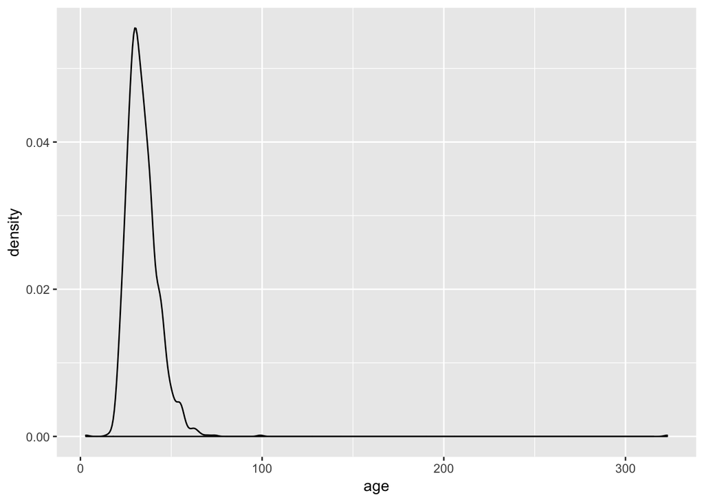

```r
mentalhealth_2016_df %>%
  ggplot(aes(x = age)) +
  geom_density()
```

```r
mentalhealth_2016_tidied =
  mentalhealth_2016_df %>%
  filter(age < 100) %>%
  mutate(gender = str_replace(gender, "^[Ww]oman$", "Female"),     # female
         gender = str_replace(gender, "^[Ff]$", "Female"),
         gender = str_replace(gender, "^fem$", "Female"),
         gender = str_replace(gender, "^female$", "Female"),
         gender = str_replace(gender, "^female/woman$", "Female"),
         gender = str_replace(gender, "^fm$", "Female"),
         gender = str_replace(gender, "AFAB", "Female"),
         #gender = str_replace(gender, "AFAB", "Female"),
         gender = str_replace(gender, "^[Mm]$", "Male"),  # male
         gender = str_replace(gender, "^mail$", "Male"),  #?
         gender = str_replace(gender, "^MALE$", "Male"),
         gender = str_replace(gender, "^Male.$", "Male"),
         gender = str_replace(gender, "^Malr$", "Male"),    #?
         gender = str_replace(gender, "^[Mm]an$", "Male"),
         #gender = str_replace(gender, "^man$", "Male"),
         gender = str_replace(gender, "^male$", "Male"))

#summary(as.factor(mentalhealth_2016_df$gender))
#summary(mentalhealth_2016_df$age)   # need filter 99 or not?

head(mentalhealth_2016_df)
```

```
## # A tibble: 6 x 63
##   self_employed num_employees tech_company tech_role benefits care_options
##           <int> <chr>                <int>     <int> <chr>    <chr>
## 1             0 26-100                   1        NA Not eli… N/A
## 2             0 6-25                     1        NA No       Yes
## 3             0 6-25                     1        NA No       N/A
## 4             1 <NA>                    NA        NA <NA>     <NA>
## 5             0 6-25                     0         1 Yes      Yes
## 6             0 More than 10…            1        NA Yes      I am not su…
## # ... with 57 more variables: employer_discussion <chr>,
## #   employer_help <chr>, anonymity <chr>, medical_leave <chr>,
## #   mental_health_consequences <chr>, physical_health_consequences <chr>,
## #   coworkers_discussion <chr>, supervisor_discussion <chr>,
## #   mental_vs_physical <chr>, obs_consequence <chr>,
## #   medical_coverage <int>, help_resourcces <chr>,
## #   whether_reveal_business_contacts <chr>,
## #   reveal_concequences_business_contects <chr>,
## #   whether_reveal_coworkers <chr>, reveal_concequences_coworkers <chr>,
## #   productivity_affect <chr>, work_time_affected <chr>,
## #   preemployers <int>, preemployers_benefits <chr>,
## #   preemployers_care_options <chr>, preemployers_discussion <chr>,
## #   preemployer_help <chr>, pre_anonymity <chr>,
## #   pre_mental_health_consequences <chr>,
## #   pre_physical_health_consequences <chr>,
## #   pre_coworkers_discussion <chr>, pre_supervisors_discussion <chr>,
## #   pre_mental_vs_physical <chr>, pre_obs_consequence <chr>,
## #   physical_health_interview <chr>,
## #   physical_health_interview_reason <chr>, mental_health_interview <chr>,
## #   mental_health_interview_reason <chr>, career_influence <chr>,
## #   coworkers_view <chr>, friends_family_share <chr>,
## #   unsupportive_badly_handled <chr>, less_likely_reveal <chr>,
## #   family_history <chr>, mental_health_previous <chr>,
## #   mental_health_now <chr>, condition_diagnosed <chr>,
## #   possible_condition <chr>, professional_diagnosed <chr>,
## #   condition_professional_diagnosed <chr>, seek_treatment <int>,
## #   work_interferes_treated <chr>, work_interferes_untreated <chr>,
## #   age <int>, gender <chr>, country_live <chr>, territory_live <chr>,
## #   country_work <chr>, territory_work <chr>, work_position_kind <chr>,
## #   work_remotely <chr>
```